# Lab 01 - Hello R

Fiona Wang

Jan-21-2025

## Load packages and data

```r
library(tidyverse)
library(datasauRus)
```

## Exercises

### Exercise 1

Based on the help file, this data set has 1846 rows and 3 columns. The three variables included in the data frame are “dataset”, “x”, and “y”.

### Exercise 2

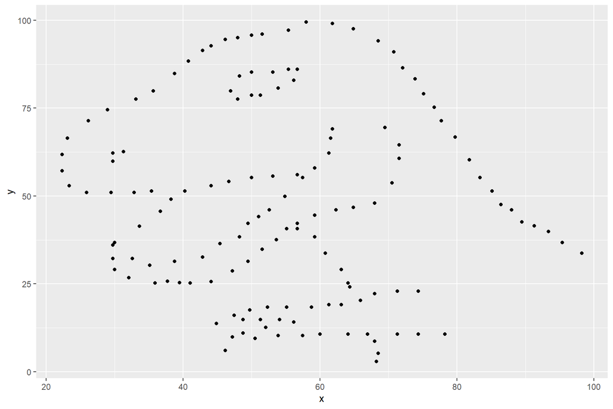

```r
dino_data <- datasaurus_dozen %>%
  filter(dataset == "dino")

ggplot(data = dino_data, mapping = aes(x = x, y = y)) +
  geom_point()
```

```r
dino_data %>%
  summarize(r = cor(x, y))
```

```
## # A tibble: 1 × 1
##         r
##     <dbl>
## 1 -0.0645
```

After plotting the data from the dino data set, we got a dinosaur-shaped graph. Even though there didn’t seem to be a linear relationship between x and y variables from observing the graph, a correlation analysis was conducted. There is a very weak and negative correlation between x and y, r = -.0645.There is no p-value to determine whether it is significant or not. But since it’s very weak, I would guess that it is not significant.

### Exercise 3

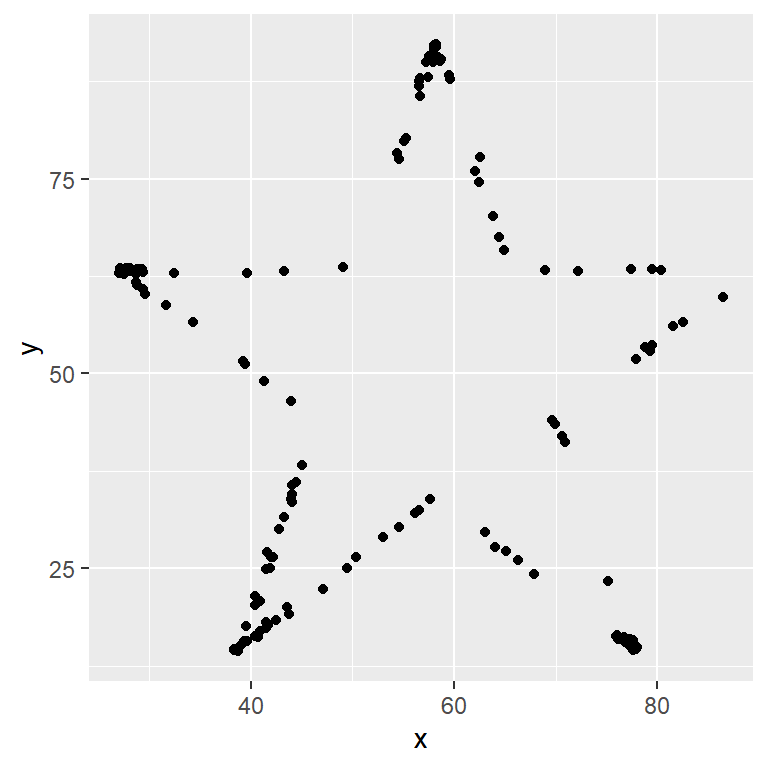

```r
star_data <- datasaurus_dozen %>%
  filter(dataset == "star")
ggplot(data = star_data, mapping = aes(x = x, y = y)) +
  geom_point()
```

The star dataset end up having a star-shaped graph after plotting x and y variables within in the dataset.

```r
star_data %>%
  summarize(r = cor(x, y))
```

```
## # A tibble: 1 × 1
##         r
##     <dbl>
## 1 -0.0630
```

From observing the graph, it didn’t seem like a linear relationship. Correlation analysis showed that there is a weak and negative relationship between x and y for the star dataset, r = -.0630. This r value is quite close to the dino dataset. Again, there is no p value for significance testing, but given that it is very weak, I think it’s not significant. Both dino and star dataset have very cool graphs, but neither has a linear relationship.

### Exercise 4

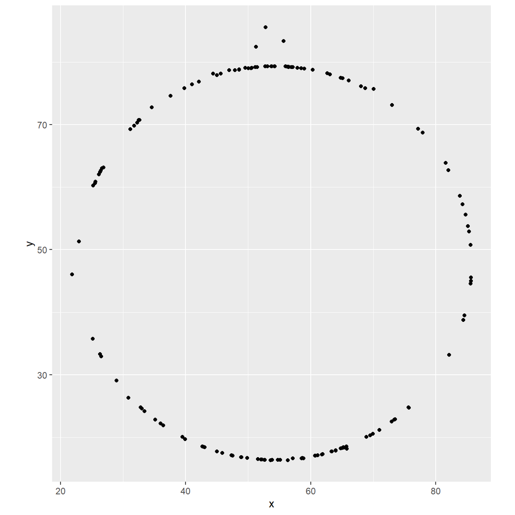

```r
circle_data <- datasaurus_dozen %>%
  filter(dataset == "circle")
ggplot(data = circle_data, mapping = aes(x = x, y = y)) +
  geom_point() +
  coord_fixed()
```

As we can see from the graph, the data points in the circle data set forms a circle-shaped graph. I also see three data points lying out of the circle.

```r
circle_data %>%
  summarize(r = cor(x,y))
```

```
## # A tibble: 1 × 1
##         r
##     <dbl>
## 1 -0.0683
```

From the correlation analysis, there is a weak and negative relationship between x and y in the circle dataset, r = -.0683. It’s slightly more negative than the dino data set, but really they are quite similar. I would guess that this is also not a significant correlation. So far, all three datasets have shapes that correspond to their names. X and y variables had no linear relationship (or very weakly negative relationship) for all three datasets.

### Exercise 5

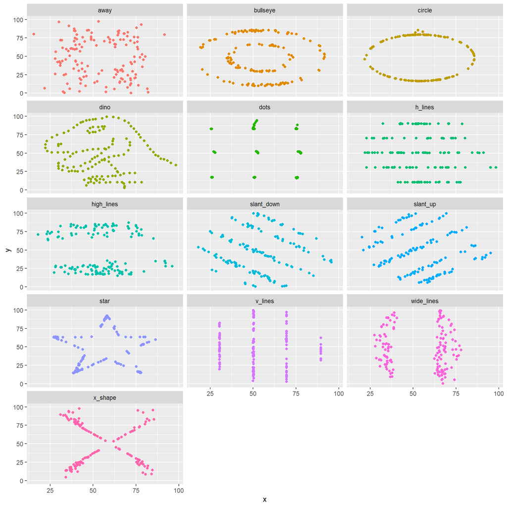

```r
ggplot(datasaurus_dozen, aes(x = x, y = y, color = dataset)) +
  geom_point() +
  facet_wrap (~dataset, ncol = 3) +
  theme(legend.position = "none")
```

It’s really cool to see all these 13 datasets!! P.S. It’s interesting that I cannot get the circle plot to look like a circle, it’s more like an oval here.

```r
datasaurus_dozen %>%
  group_by(dataset) %>%
  summarize(r=cor(x,y))
```

```
## # A tibble: 13 × 2
##    dataset          r
##    <chr>        <dbl>
##  1 away       -0.0641
##  2 bullseye   -0.0686
##  3 circle     -0.0683
##  4 dino       -0.0645
##  5 dots       -0.0603
##  6 h_lines    -0.0617
##  7 high_lines -0.0685
##  8 slant_down -0.0690
##  9 slant_up   -0.0686
## 10 star       -0.0630
## 11 v_lines    -0.0694
## 12 wide_lines -0.0666
## 13 x_shape    -0.0656
```

We can see that the correlations are all very close to each other, around -.065. This shows that x and y in all of the dataset are not correlated with each other, at least not linearly.

This is the end of Lab01.